# Bloque 3: Random Forest y su aplicación

Introducción

Profesora: Dra. Diana Paola Montoya Escobar diana.montoya@iteso.mx

Marzo 2023

[figure not shown]

[figure not shown]

# Introducción

Los modelos **Random Forest** están formados por un **conjunto de árboles de decisión individuales**, cada uno entrenado con una muestra ligeramente distinta de los datos de entrenamiento generada mediante [bootstrapping](https://towardsdatascience.com/bootstrapping-statistics-what-it-is-and-why-its-used-e2fa29577307). La predicción de una nueva observación se obtiene agregando las predicciones de todos los árboles individuales que forman un único modelo.

Los modelos **Gradient Boosting** están formados por un conjunto de **árboles de decisión** individuales, entrenados de forma secuencial, de forma que cada nuevo árbol trata de mejorar los errores de los árboles anteriores. La predicción de una nueva observación se obtiene agregando las predicciones de todos los árboles individuales que forman el modelo.

Los métodos basados en árboles se han convertido en uno de los referentes dentro del ámbito predictivo debido a los buenos resultados que generan en problemas muy diversos.

## ¿Qué es un Random Forest?

Un Random Forest es un conjunto **(ensemble)** de árboles de decisión combinados con [bagging](https://www.iartificial.net/ensembles-voting-bagging-boosting-stacking/#Bagging). Al usar bagging, lo que en realidad está pasando, es que distintos árboles ven distintas porciones de los datos. Ningún árbol ve todos los datos de entrenamiento. Esto hace que cada árbol se entrene con distintas muestras de datos para un mismo problema. De esta forma, al combinar sus resultados, unos errores se compensan con otros y tenemos una predicción que generaliza mejor.

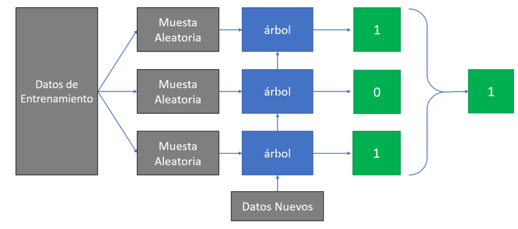

## ¿Por qué surgen los ensambladores de árboles?

Como muchos modelos, los árboles de decisión también sufre de los problemas de *sesgo y varianza*. Es decir, *cuánto en promedio son los valores predecidos diferentes de los valores reales* (sesgo) y *qué diferentes serán las predicciones de un modelo en un mismo punto si muestras diferentes se tomaran de la misma población* (varianza).

Al construir un árbol pequeño se obtendrá un modelo con baja varianza y alto sesgo (alto error). Normalmente, al incrementar la complejidad del modelo, se verá una reducción en el error de predicción debido a un sesgo más bajo en el modelo. En un punto el modelo será muy complejo y se producirá un *sobre-ajuste* del modelo el cual empezará a sufrir de varianza alta.

El modelo óptimo debería mantener un balance entre estos dos tipos de errores. A esto se le conoce como “trade-off” (equilibrio) entre errores de sesgo y varianza. El uso de ensambladores es una forma de aplicar este “trade-off”.

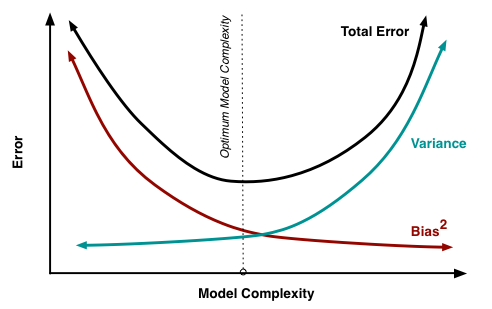

Ensambladores comunes: Bagging, Boosting and Stacking. Random Forest es del primer tipo.

## Diferencia intuitiva entre un árbol de decisión y un random forest

Para entender la diferencia, mejor pongamos un ejemplo. En la siguiente imagen puedes ver la diferencia entre el modelo aprendido por un *árbol de decisión* y un *random forest* cuando resuelven el mismo problema de regresión. Este random forest en particular, utiliza 100 árboles.

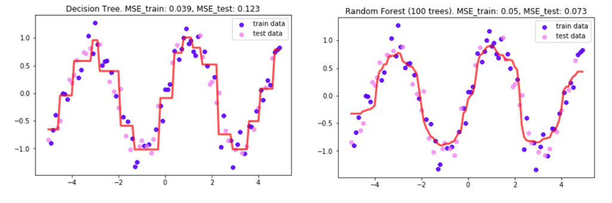

Como puedes ver, tanto el árbol de decisión como el bosque aleatorio, tienen un error cuadrático medio (MSE) de entrenamiento pequeño y similar. Sin embargo, el error de generalización del random forest es mucho mejor. Esto se puede ver también en que el modelo aprendido es mucho más suave como se puede observar en la figura.

## ¿Cómo se combinan las predicciones?

Para problemas de [*clasificación*](https://www.iartificial.net/clasificacion-o-regresion/#Clasificacion), se suelen combinar los resultados de los árboles de decisión usando soft-voting (voto suave). En el voto suave, se le da más importancia a los resultados en los que los árboles estén muy seguros.

Para problemas de [*regresión*](https://www.iartificial.net/clasificacion-o-regresion/#Clasificacion), la forma más habitual de combinar los resultados de los árboles de decisión, es tomando su media aritmética.

### Podemos inventar nuestra propia forma de combinar predicciones

También podemos inventarnos nuestra propia forma de combinar los resultados de un bosque aleatorio. Esto es posible porque podemos acceder a las predicciones individuales de cada árbol. Así, podemos hacer el uso de estas predicciones que nos interesen.

Por ejemplo, imagínate que en vez de querer predecir un resultado, queremos predecir el rango de valores probables en el futuro. Podemos obtener los valores mínimo y máximo de cada predicción para definir el intervalo más probable.

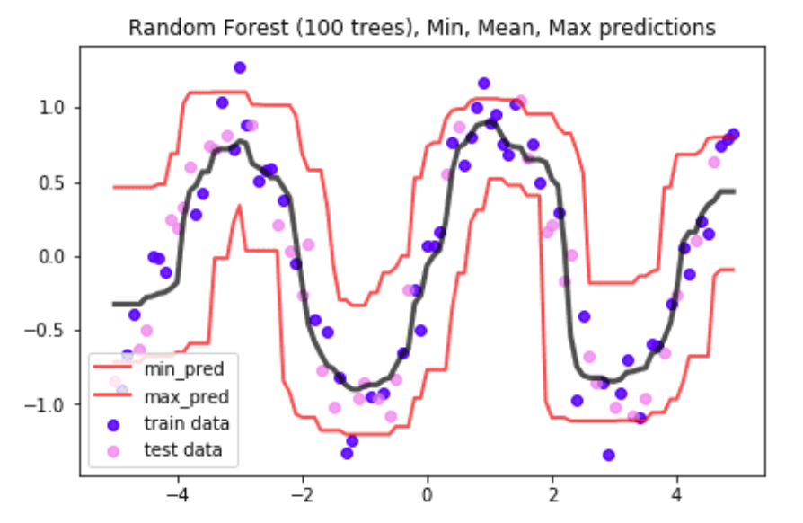

# Paquetes de R que utilizaremos

Gracias a sus buenos resultados, *Random Forest* y *Gradient Boosting*, se han convertido en los algoritmos de referencia cuando se trata con datos tabulares, de ahí que se hayan desarrollado múltiples implementaciones. Cada una tiene unas características que las hacen más adecuadas dependiendo del caso de uso. Algunos de los paquetes más empleados en R son:

- `tree` y `rpart`: permiten crear y representar árboles de regresión y clasificación.
- `randomForest`: dispone de los principales algoritmos para crear modelos random forest. Destaca por su fácil uso, pero no por su rapidez.
- `ranger`: algoritmos para crear modelos random forest. Es similar a `randomForest` pero mucho más rápido. Además, *incorpora extremely randomized trees* y [*quantile regression forests*](https://www.cienciadedatos.net/documentos/53_regresion_cuantilica_quantile_regresion_forest.html).
- `gbm`: dispone de los principales algoritmos de *boosting*. Este paquete ya no está mantenido, aunque es útil para explicar los conceptos, no se recomienda su uso en producción.
- `XGBoost`: esta librería permite acceder al algoritmo XGboost (Extra Gradient boosting). Una adaptación de gradient boosting que destaca por su eficiencia y rapidez.
- `H2O`: implementaciones muy optimizadas de los principales algoritmos de machine learning, entre ellos *random forest*, *gradient boosting* y *XGBoost*. Para conocer más detalles sobre cómo utilizar esta librería consultar módulo 1 de este curso.
- `C50`: implementación de los algoritmos *C5.0* para árboles de clasificación.

# Random Forest

Un modelo *Random Forest* está formado por un conjunto (ensemble) de árboles de decisión individuales, cada uno entrenado con una muestra aleatoria extraída de los datos de entrenamiento originales mediante [bootstrapping](https://www.cienciadedatos.net/documentos/33_arboles_decision_random_forest_gradient_boosting_c50#:~:text=Un%20modelo%20Random,ensemble%20y%20bagging.). Esto implica que cada árbol se entrena con unos datos ligeramente distintos. En cada árbol individual, las observaciones se van distribuyendo por bifurcaciones (nodos) generando la estructura del árbol hasta alcanzar un nodo terminal. La predicción de una nueva observación se obtiene agregando las predicciones de todos los árboles individuales que forman el modelo.

Para entender cómo funcionan los modelos Random Forest es necesario conocer primero los conceptos de ensemble y bagging.

# Métodos de *ensamble*

Todos los modelos de aprendizaje estadístico y machine learning sufren el problema de equilibrio entre *bias* y *varianza*.

Se entiende por **bias (sesgo)** a cuánto se alejan en promedio las predicciones de un modelo respecto a los valores reales. Refleja cómo de capaz es el modelo de aprender la relación real que existe entre los predictores y la variable respuesta. Por ejemplo, si la relación sigue un patrón no lineal, por muchos datos de los que se disponga, un modelo de regresión lineal no podrá modelar correctamente la relación, por lo que tendrá un bias alto.

La **varianza** nos indica cuánto cambia el modelo dependiendo de los datos utilizados en su entrenamiento. Idealmente, un modelo no debería modificarse demasiado por pequeñas variaciones en los datos de entrenamiento, si esto ocurre, es porque el modelo está memorizando los datos en lugar de aprender la verdadera relación entre los predictores y la variable respuesta. Por ejemplo, un modelo de árbol con muchos nodos, suele variar su estructura con que apenas cambien unos pocos datos de entrenamiento, tiene mucha varianza.

A medida que aumenta la complejidad de un modelo, este dispone de mayor flexibilidad para adaptarse a las observaciones, reduciendo así el bias y mejorando su capacidad predictiva. Sin embargo, alcanzado un determinado grado de flexibilidad, aparece el problema de [overfitting](https://www.cienciadedatos.net/documentos/33_arboles_decision_random_forest_gradient_boosting_c50#:~:text=Todos%20los%20modelos,modelo%20Random%20Forest.), el modelo se ajusta tanto a los datos de entrenamiento que es incapaz de predecir correctamente nuevas observaciones. El mejor modelo es aquel que consigue un **equilibrio óptimo entre bias y varianza**.

**¿Cómo se controlan el bias y varianza en los modelos basados en árboles?**

Por lo general, los árboles pequeños (pocas ramificaciones) tienen poca varianza pero no consiguen representar bien la relación entre las variables, es decir, tienen bias alto. Por otro lado, los árboles grandes se ajustan mucho a los datos de entrenamiento, por lo que tienen muy poco bias pero mucha varianza. Una forma de solucionar este problema son los métodos de ensemble.

Los **métodos de ensemble** combinan múltiples modelos en uno nuevo con el objetivo de lograr un equilibro entre bias y varianza, consiguiendo así mejores predicciones que cualquiera de los modelos individuales originales. Dos de los tipos de ensemble más utilizados son:

- **Bagging**: Se ajustan múltiples modelos, cada uno con un subconjunto distinto de los datos de entrenamiento. Para predecir, todos los modelos que forman el agregado participan aportando su predicción. Como valor final, se toma la media de todas las predicciones (variables continuas) o la clase más frecuente (variables categóricas). Los modelos *Random Forest* están dentro de esta categoría.
- **Boosting**: Se ajustan secuencialmente múltiples modelos sencillos, llamados weak learners, de forma que cada modelo aprende de los errores del anterior. Como valor final, al igual que en *bagging*, se toma la media de todas las predicciones (variables continuas) o la clase más frecuente (variables cualitativas). Tres de los métodos de boosting más empleados son *AdaBoost*, *Gradient Boosting* y *Stochastic Gradient Boosting*.

Aunque el objetivo final es el mismo, lograr un balance óptimo entre bias y varianza, existen dos diferencias importantes:

- Forma en que consiguen reducir el error total. El error total de un modelo puede descomponerse como bias+varianza+e. En *bagging*, se emplean modelos con muy poco bias pero mucha varianza, agregándolos se consigue reducir la varianza sin apenas inflar el bias. En *boosting*, se emplean modelos con muy poca varianza pero mucho bias, ajustando secuencialmente los modelos se reduce el bias. Por lo tanto, cada una de las estrategias reduce una parte del error total.
- Forma en que se introducen variaciones en los modelos que forman el ensemble. En bagging, cada modelo es distinto del resto porque cada uno se entrena con una muestra distinta obtenida mediante bootstrapping. En *boosting*, los modelos se ajustan secuencialmente y la importancia (peso) de las observaciones va cambiando en cada iteración, dando lugar a diferentes ajustes.

La clave para que los métodos de ensemble consigan mejores resultados que cualquiera de sus modelos individuales es que, los modelos que los forman, sean lo más diversos posibles (sus errores no estén correlacionados).

A continuación, se describe con más detalle la estrategia de bagging, sobre la que se fundamenta el modelo *Random Forest*.

## Bagging

El término *bagging* es el diminutivo de bootstrap aggregation, y hace referencia al empleo del muestreo repetido con reposición bootstrapping con el fin de reducir la varianza de algunos modelos de aprendizaje estadístico, entre ellos los basados en árboles.

Si tenemos una muestras de observaciones independientes, cada una con varianza $\sigma^2$, la varianza de la media de las observaciones Z- es $\sigma^2/n$. En otras palabras, promediando un conjunto de observaciones se reduce la varianza. Basándose en esta idea, una forma de reducir la varianza y aumentar la precisión de un método predictivo es obtener múltiples muestras de la población, ajustar un modelo distinto con cada una de ellas, y hacer la media (la moda en el caso de variables cualitativas) de las predicciones resultantes. Como en la práctica no se suele tener acceso a múltiples muestras, se puede simular el proceso recurriendo a bootstrapping, generando así simulaciones de la muestra o pseudo-muestras con los que ajustar diferentes modelos y después agregarlos. A este proceso se le conoce como **bagging** y es aplicable a una gran variedad de métodos de regresión.

En el caso particular de los árboles de decisión, dada su naturaleza de bajo bias y alta varianza, bagging ha demostrado tener muy buenos resultados. La forma de aplicarlo es:

1. Generar B pseudo-training sets mediante bootstrapping a partir de la muestra de entrenamiento original.
2. Entrenar un árbol con cada una de las B muestras del paso 1. Cada árbol se crea sin apenas restricciones y no se somete a pruning, por lo que tiene varianza alta pero poco bias. En la mayoría de casos, la única regla de parada es el número mínimo de observaciones que deben tener los nodos terminales. El valor óptimo de este hiperparámetro puede obtenerse comparando el out of bag error o por validación cruzada.
3. Para cada nueva observación, obtener la predicción de cada uno de los B árboles. El valor final de la predicción se obtiene como la media de las B predicciones en el caso de variables cuantitativas y como la clase predicha más frecuente (moda) para variables cualitativas.
4. En el proceso de bagging, el número de árboles creados no es un hiperparámetro crítico en cuanto a que, por mucho que se incremente el número, no se aumenta el riesgo de overfitting. Alcanzado un determinado número de árboles, la reducción de test error se estabiliza. A pesar de ello, cada árbol ocupa memoria, por lo que no conviene almacenar más de los necesarios.

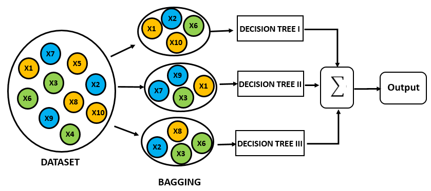

En resumen:

- Crear múltiples subconjuntos de datos
- Construir múltiples modelos
- Combinar los modelos.

## Entrenamiento de Random Forest

El algoritmo de **Random Forest* es una modificación del proceso de *bagging* que consigue mejorar los resultados gracias a que decorrelaciona aún más los árboles generados en el proceso.

Los beneficios del *bagging* se basan en el hecho de que, promediando un conjunto de modelos, se consigue reducir la varianza. Esto es cierto siempre y cuando los modelos agregados no estén correlacionados. Si la correlación es alta, la reducción de varianza que se puede lograr es pequeña.

Supóngase un set de datos en el que hay un predictor muy influyente, junto con otros moderadamente influyentes. En este escenario, todos o casi todos los árboles creados en el proceso de *bagging* estarán dominados por el mismo predictor y serán muy parecidos entre ellos. Como consecuencia de la alta correlación entre los árboles, el proceso de bagging apenas conseguirá disminuir la varianza y, por lo tanto, tampoco mejorar el modelo.

*Random forest* evita este problema haciendo una selección aleatoria de $m$ predictores antes de evaluar cada división. De esta forma, un promedio de $(p−m)/p$ divisiones no contemplarán el predictor influyente, permitiendo que otros predictores puedan ser seleccionados. Añadiendo este paso extra se consigue decorrelacionar los árboles todavía más, con lo que su agregación consigue una mayor reducción de la varianza.

Los métodos de *random forest* y *bagging* siguen el mismo algoritmo con la única diferencia de que, en random forest, antes de cada división, se seleccionan aleatoriamente $m$ predictores. La diferencia en el resultado dependerá del valor $m$ escogido. Si $m=p$ los resultados de random forest y bagging son equivalentes.

La mejor forma para encontrar el valor óptimo de $m$ es evaluar el out-of-bag-error o recurrir a validación cruzada.

Al igual que ocurre con *bagging*, *random forest* no sufre problemas de overfit por aumentar el número de árboles creados en el proceso. Alcanzado un determinado número, la reducción del error de test se estabiliza.

# Predicción de Random Forest

La predicción de un modelo Random Forest es la media de las predicciones de todos los árboles que lo forman.

Supóngase que se dispone de 10 observaciones, cada una con un valor de variable respuesta Y y unos predictores X.

| id | 1 | 2 | 3 | 4 | 5 | 6 | 7 | 8 | 9 | 10 |
| --- | --- | --- | --- | --- | --- | --- | --- | --- | --- | --- |
| Y | 10 | 18 | 24 | 8 | 2 | 9 | 16 | 10 | 20 | 14 |
| X | … | … | … | … | … | … | … | … | … | … |

A continuación se muestra cómo sería la predicción del modelo para una nueva observación. En cada árbol, el camino hasta llegar al nodo final está resaltado. En cada nodo terminal se detalla el índice de las observaciones de entrenamiento que forman parte. Aquí, en cada árbol, el camino hasta llegar al nodo final esta resatado. En cada nodo terminal se detalla el índice de las observaciones que forman parte de él.

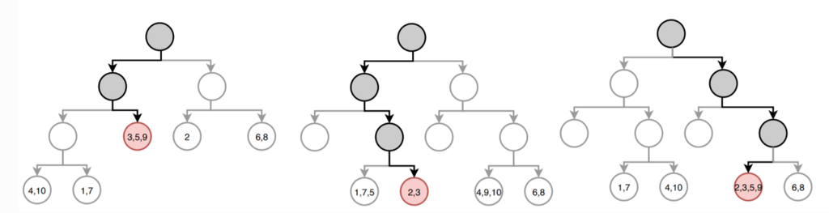

El valor predicho por cada árbol es la media de la variable respuesta Y en el nodo terminal. Acorde a la imagen, las predicciones de cada uno de los tres árboles (de izquierda a derecha) es:
$$\hat y_{árbol1}=\frac{24+2+20}{3}=15.33$$
$$\hat y_{árbol2}=\frac{18+24}{2}=21$$

$$\hat y_{árbol3}=\frac{18+24+2+20}{4}=16$$

La predicción final del modelo es la media de todas las predicciones individuales:

$$\hat \mu = \frac{15.3333+21+16}{3}=17.4$$
Aunque la anterior es la forma más común de obtener las predicciones de un modelo Random Forest, existe otra aproximación. La predicción de un árbol de regresión puede verse como una variante de vecinos cercanos en la que, solo las observaciones que forman parte del mismo nodo terminal que la observación predicha, tienen influencia. Siguiendo esta aproximación, la predicción del árbol se define como la media ponderada de todas las observaciones de entrenamiento, donde el peso de cada observación depende únicamente de si forma parte o no del mismo nodo terminal. Para Random Forest esto equivale a la media ponderada de todas las observaciones, empleando como pesos w la media de los vectores de pesos de todos los árboles.

Acorde a la imagen anterior, el vector de pesos para cada uno de los tres árboles (de izquierda a derecha) es:

$$w_{árbol1} = (0,0,1/3,0,1/3,0,0,0,1/3,0)$$
$$w_{árbol2} = (0,1/2,1/2,0,0,0,0,0,0,0)$$
$$w_{árbol3} = (0,1/4,1/4,0,1/4,0,0,0,1/4,0)$$

# Out-of-Bag Error

Dada la naturaleza del proceso de *bagging*, resulta posible estimar el error de test sin necesidad de recurrir a métodos de validación cruzada (cross-validation). El hecho de que los árboles se ajusten empleando muestras generadas por *bootstrapping* conlleva que, en promedio, cada ajuste use solo aproximadamente dos tercios de las observaciones originales. Al tercio restante se le llama *out-of-bag (OOB)*.

Si para cada árbol ajustado en el proceso de bagging se registran las observaciones empleadas, se puede predecir la respuesta de la observación i haciendo uso de aquellos árboles en los que esa observación ha sido excluida y promediándolos (la moda en el caso de los árboles de clasificación). Siguiendo este proceso, se pueden obtener las predicciones para las n observaciones y con ellas calcular el OOB-mean square error (para regresión) o el OOB-classification error (para árboles de clasificación). Como la variable respuesta de cada observación se predice empleando únicamente los árboles en cuyo ajuste no participó dicha observación, el OOB-error sirve como estimación del error de test. De hecho, si el número de árboles es suficientemente alto, el OOB-error es prácticamente equivalente al leave-one-out cross-validation error.

*Esta es una ventaja añadida de los métodos de bagging, y por lo tanto de Random Forest ya que evita tener que recurrir al proceso de validación cruzada (computacionalmente costoso) para la optimización de los hiperparámetros.*

Dos limitaciones en el uso Out-of-Bag Error:

- El *Out-of-Bag Error* no es adecuado cuando las observaciones tienen una relación temporal (series temporales). Como la selección de las observaciones que participan en cada entrenamiento es aleatoria, no respetan el orden temporal y se estaría introduciendo información a futuro.
- El preprocesado de los datos de entrenamiento se hace de forma conjunta, por lo que las observaciones out-of-bag pueden sufrir [data leakage](https://machinelearningmastery.com/data-leakage-machine-learning/) (datos que no se consideran en el modelo). De ser así, las estimaciones del OOB-error son demasiado optimistas.

En un muestreo por bootstrapping, si el tamaño de los datos de entrenamiento es $n$, cada observación tiene una probabilidad de ser elegida de $1/n$. Por lo tanto, la probabilidad de no ser elegida en todo el proceso es de $(1−1/n)/n$, lo que converge en 1/ϵ, que es aproximadamente un tercio.

## Hyper-parámetros

El hyper-parámetro más importante para ajustar es el número de variables candidatas a seleccionar para evaluar cada ramificación. Sin embargo, existen algunos adicionales que deben considerarse. Independientemente de los nombres en las distintas librerías, al menos los siguientes deberían estar presentes.

- *ntree:* número de árboles en el bosque. Se quiere estabilizar el error, pero usar demasiados árboles puede ser innecesariamente ineficiente.
- *mtry:* número de variables aleatorias como candidatas en cada ramifiación.
- *sampsize:* el número de muestras sobre las cuales entrenar. El valor por defecto es 63.25%. Valores más bajos podrían introducir sesgo y reducir el tiempo.Valores más altos podrían incrementar el rendimiento del modelo pero a riesgo de causar overfitting. Generalmente se mantiene en el rango 60-80%.
- *nodesize:* mínimo número de muestras dentro de los nodos terminales.Equilibrio entre bias-varianza
- *maxnodes:* máximo número de nodos terminales.

## Ventajas de Random Forest

Existen muy pocas suposiciones y por lo tanto la preparación de los datos es mínima.

Puede manejar hasta miles de variables de entrada e identificar las más significativas. Método de reducción de dimensionalidad. Una de las salidas del modelo es la importancia de variables. Incorpora métodos efectivos para estimar valores faltantes. Es posible usarlo como método no supervisado (clustering) y detección de outliers.

## Desventajas de Random Forest

Pérdida de interpretación. Bueno para clasificación, no tanto para regresión. Las predicciones no son de naturaleza continua. En regresión, no puede predecir más allá del rango de valores del conjunto de entrenamiento. Poco control en lo que hace el modelo (modelo caja negra para modeladores estadísticos)

## Importancia de los predictores

El hecho que el proceso de *bagging* (*Random Forest*) consigue mejorar la capacidad predictiva en comparación a los modelos basados en un único árbol, esto tiene un coste asociado, la interpretabilidad del modelo se reduce. Al tratarse de una combinación de múltiples árboles, no es posible obtener una representación gráfica sencilla del modelo y no es inmediato identificar de forma visual qué predictores son más importantes. Sin embargo, se han desarrollado nuevas estrategias para cuantificar la importancia de los predictores que hacen de los modelos de bagging (Random Forest) una herramienta muy potente, no solo para predecir, sino también para el análisis exploratorio. Dos de estas medidas son: importancia por permutación e impureza de nodos.

### Cómo se calcula

Para cada árbol en el bosque, calcule el número de votos por la clase correcta en la muestra (OOB)

Efectuar una permutación aleatoria de los valores de un predictor (e.g., variable-k) en la muestra (OOB) y verifique el número de votos por la clase correcta. Por permutuación aleatoria de una variable nos referimos a “barajar” (shuffling).

Sustraer el número de votos de la clase correcta in en los datos de variable-k permutada, del número de votos por la clase correcta en la muestra OOB original.

El promedio de este número sobre todos los árboles en el bosque es el “score” de importancia sin normalizar. Este score es normalizado a partir de la desviación estándar.

Las variables que tiene valores altos para este score son clasificadas (ranked) como las más importantes Variables having large values for this score are ranked as more important.

Esto significa que si el modelo fuera construido sin los valores originales de una variable específica, las predicciones serían peores. Por lo tanto, la variables es importante.

*La importancia de un atributo es el incremento en el error del modelo de predicción luego de que el valor de dicho atraibuto ha sido permutado (se rompre la relación entre el atributo y la salida del modelo).*

### Importancia por permutación

Identifica la influencia que tiene cada predictor sobre una determinada métrica de evaluación del modelo (estimada por out-of-bag error o validación cruzada). El valor asociado con cada predictor se obtiene de la siguiente forma:

1. Crear el conjunto de árboles que forman el modelo.
2. Calcular una determinada métrica de error (mse, classification error, …). Este es el valor de referencia (error0).
3. Para cada predictor j:
- Permutar en todos los árboles del modelo los valores del predictor j manteniendo el resto constante.
- Recalcular la métrica tras la permutación, llámese (errorj).
- Calcular el incremento en la métrica debido a la permutación del predictor j. %Incrementoj=(error−j−error0)/error0∗100

Si el predictor permutado estaba contribuyendo al modelo, es de esperar que el modelo aumente su error, ya que se pierde la información que proporcionaba esa variable. El porcentaje en que se incrementa el error debido a la permutación del predictor j puede interpretarse como la influencia que tiene j sobre el modelo. Algo que suele llevar a confusiones es el hecho de que este incremento puede resultar negativo. Si la variable no contribuye al modelo, es posible que, al reorganizarla aleatoriamente, solo por azar, se consiga mejorar ligeramente el modelo, por lo que (errorj−error0) es negativo. A modo general, se puede considerar que estas variables tienen una importancia próxima a cero.

Aunque esta estrategia suele ser la más recomendada, cabe tomar algunas precauciones en su interpretación. Lo que cuantifican es la influencia que tienen los predictores sobre el modelo, no su relación con la variable respuesta. ¿Por qué es esto tan importante? Supóngase un escenario en el que se emplea esta estrategia con la finalidad de identificar qué predictores están relacionados con el peso de una persona, y que dos de los predictores son: el índice de masa corporal (IMC) y la altura. Como IMC y altura están muy correlacionados entre sí (la información que aportan es redundante), cuando se permute uno de ellos, el impacto en el modelo será mínimo, ya que el otro aporta la misma información. Como resultado, estos predictores aparecerán como poco influyentes aun cuando realmente están muy relacionados con la variable respuesta. Una forma de evitar problemas de este tipo es, siempre que se excluyan predictores de un modelo, comprobar el impacto que tiene en su capacidad predictiva.

### Incremento de la pureza de nodos

Cuantifica el incremento total en la pureza de los nodos debido a divisiones en las que participa el predictor (promedio de todos los árboles). La forma de calcularlo es la siguiente: en cada división de los árboles, se registra el descenso conseguido en la medida empleada como criterio de división (índice Gini, mse entropía, …). Para cada uno de los predictores, se calcula el descenso medio conseguido en el conjunto de árboles que forman el ensemble. Cuanto mayor sea este valor medio, mayor la contribución del predictor en el modelo.

### Ventajas

*Fácil interpretación:* Importancia de atributos es el incremento del error del modelo cuando la información del atributo se “destruye”.

Provee una visión resumida y global del comportamiento del modelo.

La medida de la importancia toma automáticamente en cuenta todas las interacciones con otros atributos. A través de la permutación del atributo también se destruyen los efectos de interacción con otros atributos. Es decir que tanto el efecto principal como relacional de atributos se ven afectados por la permutación del atributo.

Esta es también una desventaja pues la importancia de la interacción entre dos atributos se incluirá en la medida de importancia de ambos. Esto significa que las importancias de los atributos no afectan acumulativamente al rendimiento del modelo. Solamente cuando no existe interacción entre los atributos, como en el caso de un modelo lineal, las importancias podrían representar gruesamente un efecto acumulado respecto al rendimiento del modelo.

No se requiere re-entrenar el modelo. Otros métodos sugieren eliminar un atributo, re-entrenar el modelo y comparar el error del modelo. Esto último podría parecer intuitivo, no obstante un modelo reducido es inútil para identificar la importancia del atributo. Ejm: en un árbol de decisión se quiere analizar la importaacia del atributo escogido como primera ramificación. Se remueve el atributo y se re-entrena el modelo. Como un nuevo atributo será escogido como primera ramificación, la estructura del árbol podría ser muy diferente, lo cual podría derivar en la comparación de árboles completamente diferentes.

### Desventajas

La medida de importancia de atributos está ligada al error del model. En algunos casos sería preferible saber cuánto varía la salida del modelo para un atributo ignorando como afecta en el rendimiento. Ejemplo: Se quisiera identificar cuan robusta es la salida del modelo dado que que alguien manipula los atributos. En ese caso no nos interesaría saber cuanto disminuyó el rendimiento del modelo, sino más bien cuánta de la varianza es explicada por cada atributo.

Se necesita tener acceso a las observaciones de la variable objetivo.

El proceso de permutación añade aleatoriedad a la medida de importancia del atributo. Si el proceso de permutación se repite, los resultados podrían ser diferentes. Repetir la permutación y promediar las medida de importancia sobre varias repeticiones estabiliza la métrica pero incrementa el tiempo de cómputo.

Cuando los atributos están correlacionados, la medida de importancia de atributos puede estar sesgada por datos de instancias no realistas. La permutación de los atributos genera instancias poco probables cuando dos atributos están correlacionados. Ejemplo: cuando los atributos están correlacionados positiviamente (como la altura y el peso de una persona) y al permutar uno de los atributos se crean instancias poco probables o incluso físicamente imposibles (persona de 2m con peso de 30Kg.). No obstante estas nuevas instancias se usan para el cálculo de la importancia. Podría penalizar a mi modelo por observaciones generadas que nunca ocurrirán en la realidad.

Verificar si los atributos están fuertemente correlacionados y ser cuidadoso con la interpretación de la importancia de atributos.

Añadir un atributo correlacionado puede reducir la importancia del atributo asociado y “dividir” la importancia de ambos atributos. Ejemplo.

Se desea predecir la probabilidad de lluvia y se usa la temperatura a las 8:00 AM del día anterior junto a otros atributos no correlacionados.

Otro escenario donde adicionalmente incluimos la temperaturo a las 9:00 AM el cual es altamente correlacionado con la temperatura a las 8:00 AM.

# Referencias

- [data leakage](https://machinelearningmastery.com/data-leakage-machine-learning/)
- bootstrapping
- [bagging](https://www.iartificial.net/ensembles-voting-bagging-boosting-stacking/#Bagging)
- [Árboles de decisión, random forest, gradient boosting y C5.0](https://www.cienciadedatos.net/documentos/33_arboles_decision_random_forest_gradient_boosting_c50#Idea_intuitiva), Joaquín Amat, 2020